# Correction TP 1 : Jeux de données et variables

- Montrer tout le code
- Cacher tout le code
- Voir les sources

Auteur·rice

HAMLIL Mohamed

Date de publication

2 mars 2026

# Exercice 0 : Prise en main

J’aime utiliser **RStudio**, une interface du logiciel `R` qui est bien pratique car elle comprend :

- Une fenêtre contenant notre script `R`.
- Une fenêtre console pour exécuter des commandes (comme dans `R`).
- Une fenêtre contenant les onglets Environment (environnement).
- Une fenêtre contenant les onglets Plots (graphiques), Packages, Help (aide).

**AstuceInstallation**

Pour installer `RStudio` c’est [ici](https://posit.co/download/rstudio-desktop/#download).

`R Markdown` (et `Quarto`) permet de créer un document avec du texte, des extraits de code `R` et leurs résultats, et d’obtenir un beau PDF.  
[Plus d’informations ici](https://rmarkdown.rstudio.com/lesson-1.html).

## 1. Installer un package

Le *Comprehensive R Archive Network* (CRAN) est le répertoire officiel de packages `R`. Avant de pouvoir utiliser un package, il faut s’assurer qu’il soit installé sur notre machine.

Pour installer un package, on utilise la commande `install.packages`.

**Avertissement**

Attention aux guillemets ! Sinon, R cherchera une variable nommée `tinytex` au lieu du package.

```r
install.packages("tinytex")
install.packages("rmarkdown")
```

**NoteÀ faire**

Installer le package `faraway` que l’on trouve dans CRAN.

```r
install.packages("faraway")
```

*Note : On utilise `eval=FALSE` dans le RMarkdown pour ne pas réinstaller le package à chaque compilation du PDF.*

## 2. Charger un package

Une fois qu’un package est installé, il faut le charger avec la commande `library`.

```r
library(faraway)
```

**NoteÀ faire**

Installer et charger le package `ggplot2`.

```r
install.packages("ggplot2")
```

```r
library(ggplot2)
```

## 3. Documentation du package

On accède à la documentation via l’onglet *Packages* ou directement via la commande `?`. Par exemple, pour le jeu de données `pima` du package `faraway` :

```r
?pima
```

**NoteÀ faire**

Accéder à la documentation du jeu de données `beetle`.

## 4. Variables

Il est recommandé de commencer avec un environnement propre.

```r
rm(list = ls())
```

Les variables stockent des données. Règles de nommage:

1. Ne peut pas commencer par un chiffre.
2. Uniquement caractères alphanumériques et underscores (`_`) ou points (`.`).
3. Sensible à la casse (`az9_8` `Az9_8`).

**Important**

Attention à ne pas utiliser des noms réservés (comme `mean`, `c`, `data`) pour éviter des conflits.

**Assignation** : On utilise `<-` (préférable en R) ou `=`.

```r
az9_8 = 7
```

**Gestion** :

- `ls()` : Lister les objets.
- `rm()` : Supprimer un objet.

```r
ls()
```

```
[1] "az9_8"
```

```r
rm(az9_8)
```

## 5. Types de données dans `R`

Les types principaux sont :

- `numeric` : nombres réels.
- `integer` : entiers (ex: `2L`).
- `character` : texte.
- `logical` : booléen (`TRUE`, `FALSE`).
- `factor` : variable catégorielle.

```r
class(2)
```

```
[1] "numeric"
```

```r
class(2L)
```

```
[1] "integer"
```

```r
class("texte")
```

```
[1] "character"
```

```r
class(TRUE)
```

```
[1] "logical"
```

## 6. Opérations

**Séquences** : L’opérateur `:` génère une séquence d’entiers.

```r
1:50
```

```
 [1]  1  2  3  4  5  6  7  8  9 10 11 12 13 14 15 16 17 18 19 20 21 22 23 24 25
[26] 26 27 28 29 30 31 32 33 34 35 36 37 38 39 40 41 42 43 44 45 46 47 48 49 50
```

**Arithmétique** : `+`, `-`, `*`, `/`, `^` (puissance). **Assignation** : `=` ou `<-`.

```r
x = 2
y = (-1)^2
z = 10 / 3
w = "lapin"
class(w)
```

```
[1] "character"
```

**Comparaison** : `==` (égalité), `!=` (différence), `>`, `<`, `>=`, `<=`.

```r
x != y
```

```
[1] TRUE
```

**Logique et Contrôle** : `&` (ET), `|` (OU), `!` (NON), `if`, `else`, `for`, `while`.

```r
if(z < 2){
  z = "petit"
} else {
  z = "grand"
}
z
```

```
[1] "grand"
```

**Accès** :

- `[ ]` : accès par index (vecteurs, matrices).
- `$` : accès par nom (listes, data frames).

## 7. Vecteurs

On crée un vecteur avec `c()` (combine).

```r
v = c(1, 2, 4)
w = 100:150       # Séquence
z = rep("souris", times = 5) # Répétition (réduit à 5 pour l'affichage)
y = seq(from = 0, to = 1, by = 0.1) # Séquence avec pas
```

**Indexation** : Les indices commencent à **1**.

```r
v[3]        # 3ème élément
```

```
[1] 4
```

```r
v[-2]       # Tout sauf le 2ème
```

```
[1] 1 4
```

```r
w[c(1, 10)] # 1er et 10ème éléments
```

```
[1] 100 109
```

**Conversion de type** :

```r
v_char = c("a","b","c","a","c","c")
w_fact = as.factor(v_char) # Conversion en facteur
levels(w_fact)
```

```
[1] "a" "b" "c"
```

## 8. Quelques fonctions usuelles

**Lois de probabilité** :

- `r...` (random) : génération aléatoire.
- `d...` (density) : densité.
- `p...` (probability) : fonction de répartition.
- `q...` (quantile) : quantiles.

```r
# Echantillonnage
x = runif(n = 10, min = 0, max = 1)
y = rbinom(n = 10, size = 1, prob = 0.5)

# Tirage avec/sans remise
sample(x = 1:10, size = 5, replace = FALSE)
```

```
[1] 4 5 9 8 6
```

**Statistiques descriptives** :

```r
x = rnorm(n = 1000, mean = 5, sd = 2)
mean(x)
```

```
[1] 5.082118
```

```r
var(x)
```

```
[1] 3.867141
```

```r
summary(x)
```

```
   Min. 1st Qu.  Median    Mean 3rd Qu.    Max.
-0.4523  3.7872  5.1160  5.0821  6.3887 11.0700
```

**Tri** : `sort()` (trie les valeurs) et `order()` (donne les indices).

```r
v = c(1, 10, 3, 8, -5)
sort(v, decreasing = TRUE)
```

```
[1] 10  8  3  1 -5
```

```r
order(v)
```

```
[1] 5 1 3 4 2
```

## 9. Matrices

Création avec `matrix()`.

```r
M = matrix(c(1,2,3,4,5,6), nrow = 2, ncol = 3, byrow = TRUE)
P = matrix(c(1,2,3,4,5,6), nrow = 2, ncol = 3, byrow = FALSE)
```

**Opérations** :

- `dim()`, `nrow()`, `ncol()` : dimensions.
- `t()` : transposée.
- `%*%` : produit matriciel.
- `solve()` : inverse.
- `diag()` : diagonale.

**NoteExercice**

```r
P = matrix(rbinom(n = 25, size = 1, prob = 0.6), nrow = 5, ncol = 5)
Q = diag(diag(P))
```

## 10. Listes

Les listes peuvent contenir des objets de types différents.

```r
l = list(vecteur = 1:10, noms = c("lapin","souris"))
l$noms # Accès par nom
```

```
[1] "lapin"  "souris"
```

## 11. Données manquantes et valeurs spéciales

- `NA` : Not Available (manquant).
- `NaN` : Not a Number (0/0).
- `Inf` : Infini.

```r
x = c(1, 2, NA)
is.na(x)
```

```
[1] FALSE FALSE  TRUE
```

## 12. Écrire une fonction

```r
g = function(x, y = 2){ # y a une valeur par défaut de 2
  z = x + y
  return(list(res_x = x, res_z = z))
}

# Appel de la fonction
g(x = 1) # utilise y = 2 par défaut
```

```
$res_x
[1] 1

$res_z
[1] 3
```

## 13. Data Frames

Structure classique des données : colonnes = variables, lignes = individus.

```r
d = data.frame(
  x = rep(1, 10),
  y = 1:10,
  char = letters[1:10]
)
head(d)
```

```
  x y char
1 1 1    a
2 1 2    b
3 1 3    c
4 1 4    d
5 1 5    e
6 1 6    f
```

## 14. Charger un jeu de données

- Via un package : `data(pima)` (package `faraway`).
- Via un fichier : `read.csv()`.

```r
# Exemple si le fichier est dans le dossier parent
data = read.csv("../titanic.csv")
```

## 15. Fonctions graphiques de base

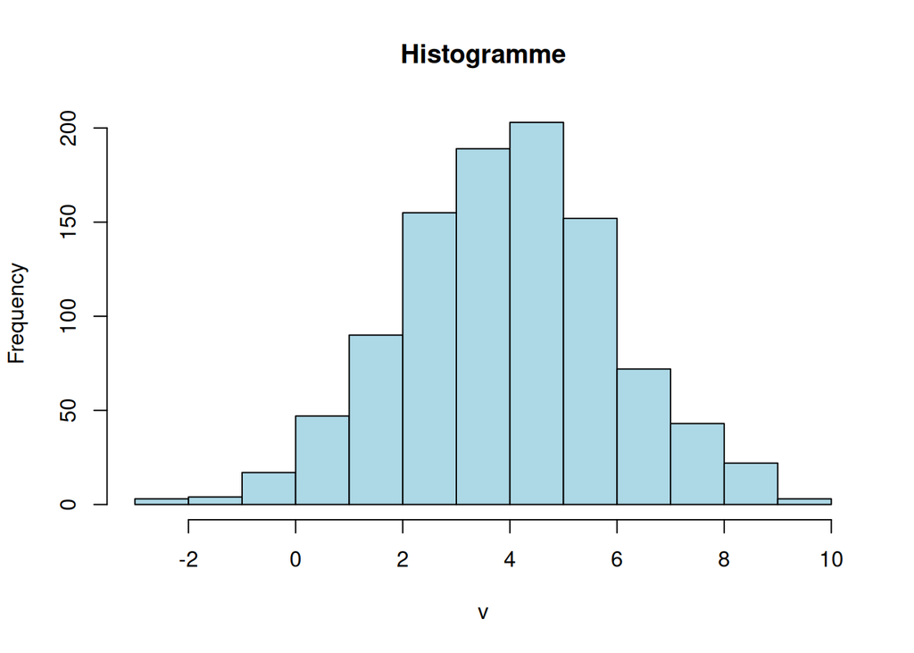

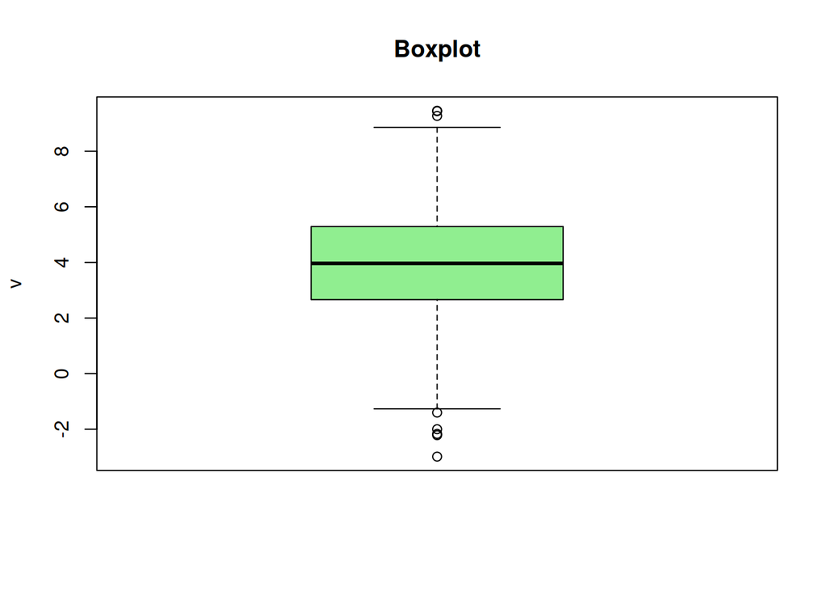

```r
v = rnorm(1000, mean = 4, sd = 2)

# Histogramme
hist(v, col = "lightblue", main = "Histogramme", xlab = "v")
# Boxplot
boxplot(v, col = 'lightgreen', main = "Boxplot", ylab = "v")
```

**Paramètres graphiques** :

- `par(mfrow = c(1,2))` : divise la fenêtre en 1 ligne, 2 colonnes.
- `ylim`, `xlim` : limites des axes.
- `main`, `xlab`, `ylab` : titres et labels.

# Exercice 1 : Analyse préliminaire d’un jeu de données

## 1. Charger et inspecter les données

Le jeu donnée `pima` est dans le package `faraway`.

```r
data(pima)
head(pima)
```

```
  pregnant glucose diastolic triceps insulin  bmi diabetes age test
1        6     148        72      35       0 33.6    0.627  50    1
2        1      85        66      29       0 26.6    0.351  31    0
3        8     183        64       0       0 23.3    0.672  32    1
4        1      89        66      23      94 28.1    0.167  21    0
5        0     137        40      35     168 43.1    2.288  33    1
6        5     116        74       0       0 25.6    0.201  30    0
```

**Dimensions** :

```r
nrow(pima) # 768 lignes
```

```
[1] 768
```

```r
ncol(pima) # 9 colonnes
```

```
[1] 9
```

**Types de variables** :

```r
str(pima) # Donne une vue d'ensemble compacte des types
```

```
'data.frame':   768 obs. of  9 variables:
 $ pregnant : int  6 1 8 1 0 5 3 10 2 8 ...
 $ glucose  : int  148 85 183 89 137 116 78 115 197 125 ...
 $ diastolic: int  72 66 64 66 40 74 50 0 70 96 ...
 $ triceps  : int  35 29 0 23 35 0 32 0 45 0 ...
 $ insulin  : int  0 0 0 94 168 0 88 0 543 0 ...
 $ bmi      : num  33.6 26.6 23.3 28.1 43.1 25.6 31 35.3 30.5 0 ...
 $ diabetes : num  0.627 0.351 0.672 0.167 2.288 ...
 $ age      : int  50 31 32 21 33 30 26 29 53 54 ...
 $ test     : int  1 0 1 0 1 0 1 0 1 1 ...
```

### Transformation de variables

**Variable catégorielle** : `age`. Plusieurs stratégies de discrétisation :

1. Intervalles de même largeur (`cut`).
2. Intervalles avec même effectif (quantiles).
3. Groupes sémantiques (Enfant, Adulte, Senior).

Application (Groupes sémantiques) :

```r
pima$age_cat  = cut(pima$age,
                    breaks = c(21, 30, 55, 65, 81),
                    include.lowest = TRUE)
```

## 2. Analyse statistique univariée

Pour les variables **quantitatives** : moyenne, variance, quartiles. Pour les variables **qualitatives** : tables de contingence.

```r
summary(pima)
```

```
    pregnant         glucose        diastolic         triceps
 Min.   : 0.000   Min.   :  0.0   Min.   :  0.00   Min.   : 0.00
 1st Qu.: 1.000   1st Qu.: 99.0   1st Qu.: 62.00   1st Qu.: 0.00
 Median : 3.000   Median :117.0   Median : 72.00   Median :23.00
 Mean   : 3.845   Mean   :120.9   Mean   : 69.11   Mean   :20.54
 3rd Qu.: 6.000   3rd Qu.:140.2   3rd Qu.: 80.00   3rd Qu.:32.00
 Max.   :17.000   Max.   :199.0   Max.   :122.00   Max.   :99.00
    insulin           bmi           diabetes           age
 Min.   :  0.0   Min.   : 0.00   Min.   :0.0780   Min.   :21.00
 1st Qu.:  0.0   1st Qu.:27.30   1st Qu.:0.2437   1st Qu.:24.00
 Median : 30.5   Median :32.00   Median :0.3725   Median :29.00
 Mean   : 79.8   Mean   :31.99   Mean   :0.4719   Mean   :33.24
 3rd Qu.:127.2   3rd Qu.:36.60   3rd Qu.:0.6262   3rd Qu.:41.00
 Max.   :846.0   Max.   :67.10   Max.   :2.4200   Max.   :81.00
      test          age_cat
 Min.   :0.000   [21,30]:417
 1st Qu.:0.000   (30,55]:301
 Median :0.000   (55,65]: 37
 Mean   :0.349   (65,81]: 13
 3rd Qu.:1.000
 Max.   :1.000
```

**Avertissement**

Anomalies détectées

- `test` est binaire (0/1) mais vue comme numérique.
- `diastolic` (pression sanguine) a des valeurs à 0, ce qui est impossible physiologiquement. Cela indique des données manquantes.

**Correction des données** :

```r
# Conversion en facteur
pima$test = as.factor(pima$test)
levels(pima$test) = c("négatif","positif")

# Remplacement des 0 par NA
vars_to_fix = c("diastolic", "glucose", "triceps", "insulin", "bmi")
for(v in vars_to_fix){
  pima[pima[[v]] == 0, v] = NA
}

summary(pima)
```

```
    pregnant         glucose        diastolic         triceps
 Min.   : 0.000   Min.   : 44.0   Min.   : 24.00   Min.   : 7.00
 1st Qu.: 1.000   1st Qu.: 99.0   1st Qu.: 64.00   1st Qu.:22.00
 Median : 3.000   Median :117.0   Median : 72.00   Median :29.00
 Mean   : 3.845   Mean   :121.7   Mean   : 72.41   Mean   :29.15
 3rd Qu.: 6.000   3rd Qu.:141.0   3rd Qu.: 80.00   3rd Qu.:36.00
 Max.   :17.000   Max.   :199.0   Max.   :122.00   Max.   :99.00
                  NA's   :5       NA's   :35       NA's   :227
    insulin            bmi           diabetes           age
 Min.   : 14.00   Min.   :18.20   Min.   :0.0780   Min.   :21.00
 1st Qu.: 76.25   1st Qu.:27.50   1st Qu.:0.2437   1st Qu.:24.00
 Median :125.00   Median :32.30   Median :0.3725   Median :29.00
 Mean   :155.55   Mean   :32.46   Mean   :0.4719   Mean   :33.24
 3rd Qu.:190.00   3rd Qu.:36.60   3rd Qu.:0.6262   3rd Qu.:41.00
 Max.   :846.00   Max.   :67.10   Max.   :2.4200   Max.   :81.00
 NA's   :374      NA's   :11
      test        age_cat
 négatif:500   [21,30]:417
 positif:268   (30,55]:301
               (55,65]: 37
               (65,81]: 13
```

## 3. Analyse graphique univariée

Variable Quantitative : Pression sanguine (`diastolic`)

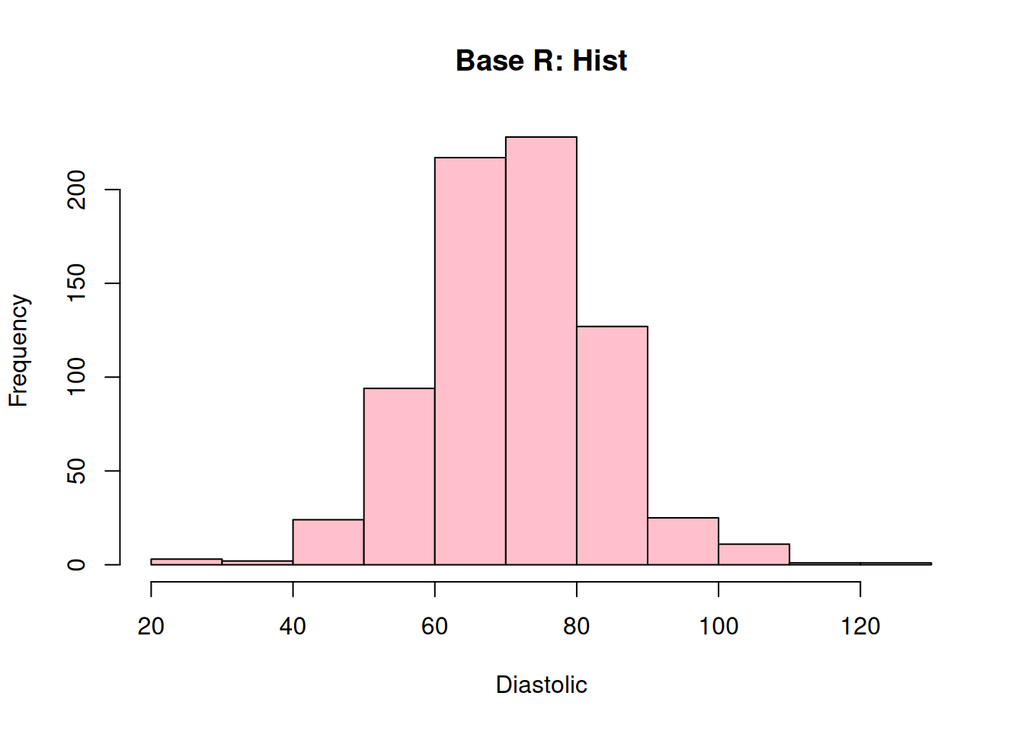

Distribution de la pression diastolique

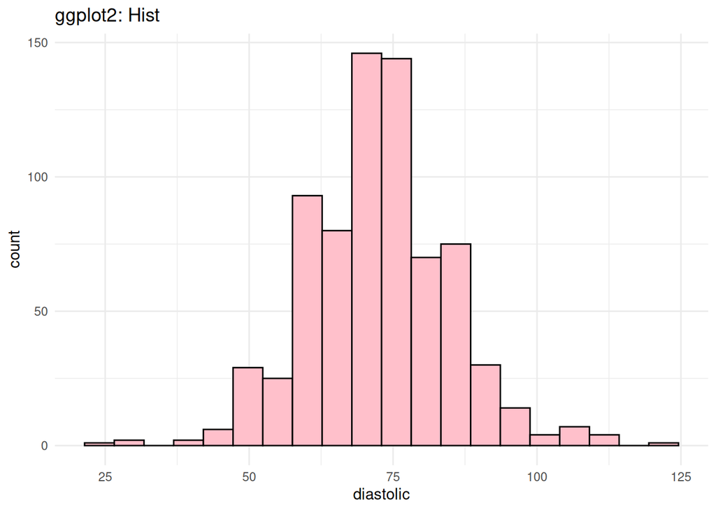

Distribution de la pression diastolique

```r
# Base R
hist(pima$diastolic, col = "pink", main = "Base R: Hist", xlab = "Diastolic")
# ggplot2
ggplot(pima, aes(x = diastolic)) +
  geom_histogram(fill = "pink", color = "black", bins = 20, na.rm = TRUE) +
  labs(title = "ggplot2: Hist") + theme_minimal()
```

Variable Qualitative : Age catégorisé

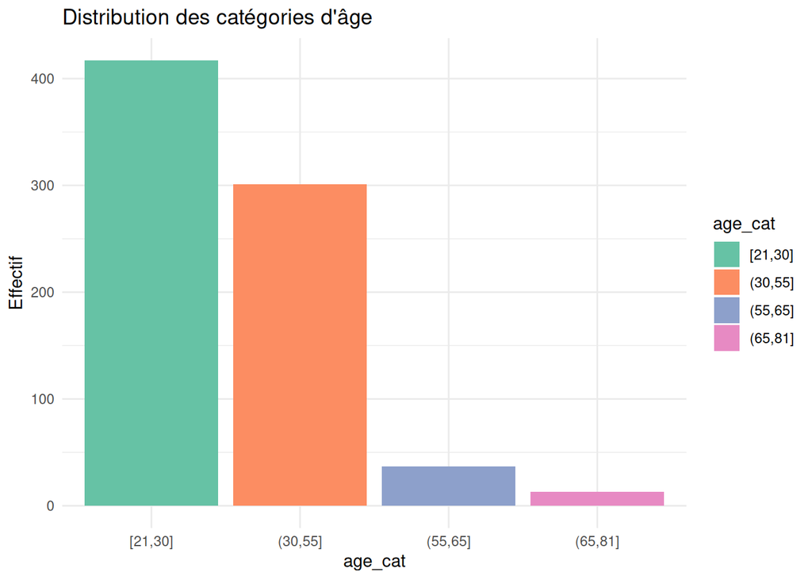

```r
ggplot(pima, aes(x = age_cat, fill = age_cat)) +
  geom_bar() +
  scale_fill_brewer(palette = "Set2") +
  labs(title = "Distribution des catégories d'âge", y = "Effectif") +
  theme_minimal()
```

## 4. Analyse multivariée

Deux variables quantitatives (`diabetes` vs `diastolic`)

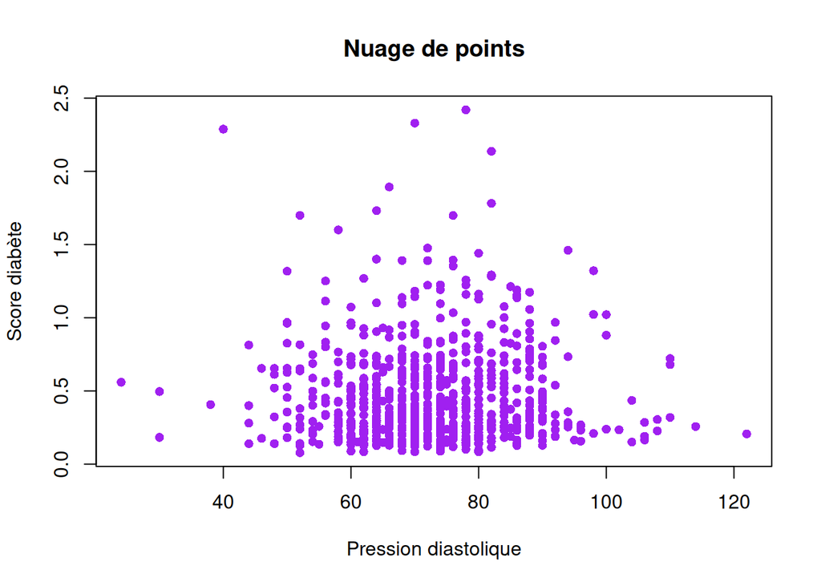

```r
plot(pima$diastolic, pima$diabetes, col = "purple", pch = 16,
     xlab = "Pression diastolique", ylab = "Score diabète",
     main = "Nuage de points")
```

Pour voir toutes les relations 2 à 2 : `pairs()`

### Quantitative vs Qualitative (`diabetes` vs `test`)

On utilise des **boxplots**.

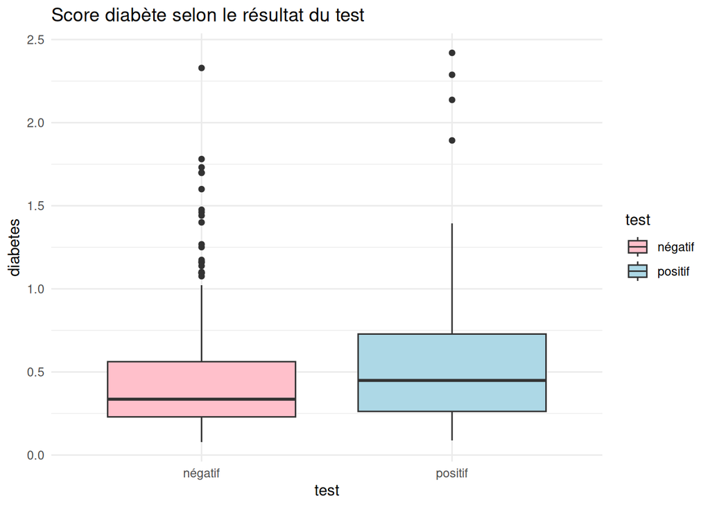

```r
ggplot(pima, aes(x = test, y = diabetes, fill = test)) +
  geom_boxplot() +
  scale_fill_manual(values = c("pink", "lightblue")) +
  labs(title = "Score diabète selon le résultat du test") +
  theme_minimal()
```

### Deux variables qualitatives (`age_cat` vs `test`)

On utilise des **barplots empilés**.

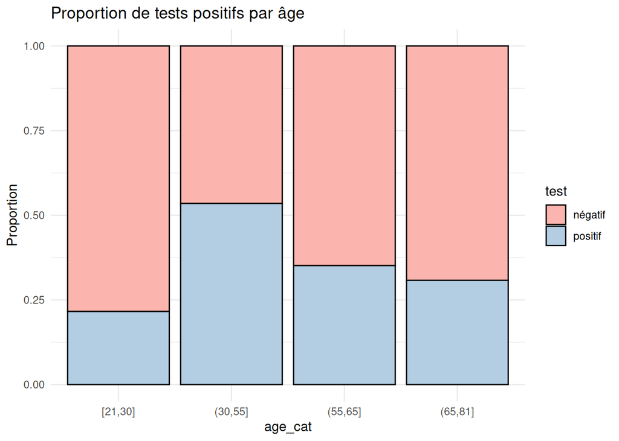

```r
# Barplot proportionnel (position = "fill")
ggplot(pima, aes(x = age_cat, fill = test)) +
  geom_bar(position = "fill", color = "black") +
  scale_fill_brewer(palette = "Pastel1") +
  labs(y = "Proportion", title = "Proportion de tests positifs par âge") +
  theme_minimal()
```